# K-fold Factor Analysis - Lebanon Students

September 21, 2021

# Overview

**# of folds:** 10

**# of variables:** 21

**# of observations:** 8027

**Maximum # of factors:**

- Allowed - 5
- Extracted - 4

**Estimation:** DWLS

**Missing Data:** listwise

# Model Summary

**Fit across folds by factor model**

[output not shown]

**Count of folds out of 10 with flagged problems**

[output not shown]

*Notes:*  
‘mode structure’ is the number of folds the EFA identified the mode (most common) structure. Thus, “mode structure” will be 10 when the same structure was identified in every fold and < 10 when multiple factor structures were identified. The value in “mode structure” is maximum for all remaining columns. The mode structure was used in the CFA. See Appendix for all structures.  
‘improper solution’ is the number of folds with non-convergence or a non-positive definite matrix.  
‘high factor correlation’ threshold set to 0.9.  
‘low scale reliability’ threshold set to 0.6 with $\omega_h$.  
‘low loading’ threshold set to 0.3.  
blanks = not applicable

# Model Details

## 1-factor

**Factor Structure**

f1 =~ a1101x + a1102x + a1103x + a1104x + a1105x + a1106x + a1107x + a1108x + a1109x + a1110x + a1111x + a1112x + a1113x + a1114x + a1115x + a1116x + a1117x + a1118x + a1119x + a1120x + a1121x

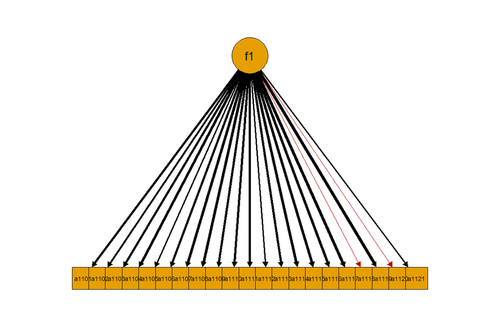

**Standardized Loading Across Folds**

| variable | mean | range | loading flag | heywood flag |
| --- | --- | --- | --- | --- |
| a1101x | 0.69 | 0.61 - 0.78 | 0 | 0 |
| a1102x | 0.58 | 0.51 - 0.64 | 0 | 0 |
| a1103x | 0.63 | 0.58 - 0.66 | 0 | 0 |
| a1104x | 0.74 | 0.70 - 0.78 | 0 | 0 |
| a1105x | 0.47 | 0.43 - 0.55 | 0 | 0 |
| a1106x | 0.70 | 0.67 - 0.72 | 0 | 0 |
| a1107x | 0.77 | 0.74 - 0.79 | 0 | 0 |
| a1108x | 0.76 | 0.72 - 0.79 | 0 | 0 |
| a1109x | 0.62 | 0.59 - 0.66 | 0 | 0 |
| a1110x | 0.67 | 0.62 - 0.71 | 0 | 0 |
| a1111x | 0.70 | 0.64 - 0.75 | 0 | 0 |
| a1112x | 0.48 | 0.42 - 0.54 | 0 | 0 |
| a1113x | 0.66 | 0.62 - 0.69 | 0 | 0 |
| a1114x | 0.80 | 0.77 - 0.83 | 0 | 0 |
| a1115x | 0.75 | 0.70 - 0.80 | 0 | 0 |
| a1116x | 0.78 | 0.75 - 0.82 | 0 | 0 |
| a1117x | 0.85 | 0.82 - 0.88 | 0 | 0 |
| a1118x | 0.32 | 0.21 - 0.39 | 4 | 0 |
| a1119x | 0.84 | 0.81 - 0.86 | 0 | 0 |
| a1120x | 0.34 | 0.24 - 0.40 | 1 | 0 |
| a1121x | 0.48 | 0.41 - 0.53 | 0 | 0 |

Note: loadings flagged when < 0.3 in a fold. ‘heywood flag’ is the number of folds the variable’s estimated residual variance was negative

**Scale Reliability Across Folds**

| factor | omega_h mean | omega_h range | omega_h flag | alpha mean | alpha range | alpha flag |
| --- | --- | --- | --- | --- | --- | --- |
| f1 | 0.92 | 0.91 - 0.92 | 0 | 0.94 | 0.93 - 0.94 | 0 |

Note: ‘flag’ is the number of folds the scale had a reliability < 0.6

## 2-factor

**Factor Structure**

f1 =~ a1101x + a1102x + a1103x + a1104x + a1105x + a1106x + a1107x + a1108x + a1109x + a1110x + a1111x + a1112x + a1113x + a1114x + a1115x + a1116x + a1117x + a1119x

f2 =~ a1118x + a1120x + a1121x

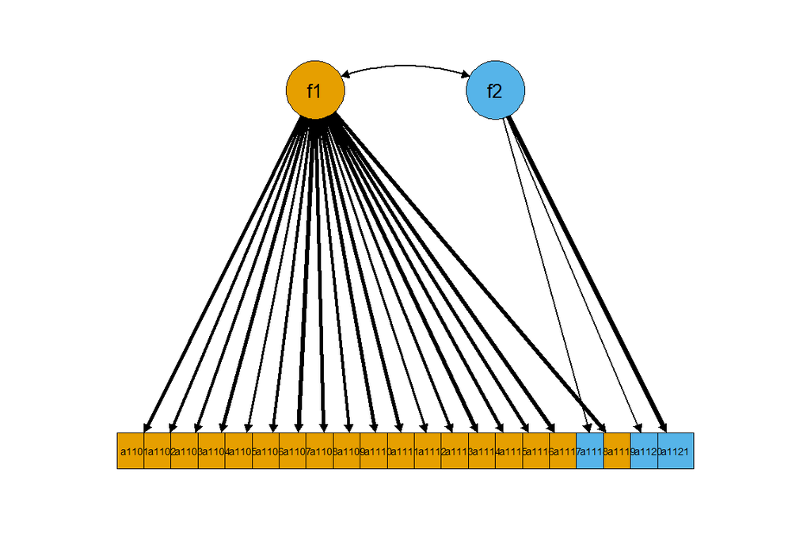

**Standardized Loading Across Folds**

| variable | mean | range | loading flag | heywood flag |
| --- | --- | --- | --- | --- |
| a1101x | 0.69 | 0.61 - 0.78 | 0 | 0 |
| a1102x | 0.58 | 0.52 - 0.64 | 0 | 0 |
| a1103x | 0.64 | 0.58 - 0.67 | 0 | 0 |
| a1104x | 0.75 | 0.70 - 0.78 | 0 | 0 |
| a1105x | 0.47 | 0.43 - 0.55 | 0 | 0 |
| a1106x | 0.71 | 0.67 - 0.73 | 0 | 0 |
| a1107x | 0.77 | 0.74 - 0.79 | 0 | 0 |
| a1108x | 0.76 | 0.72 - 0.80 | 0 | 0 |
| a1109x | 0.63 | 0.60 - 0.67 | 0 | 0 |
| a1110x | 0.67 | 0.62 - 0.71 | 0 | 0 |
| a1111x | 0.71 | 0.64 - 0.75 | 0 | 0 |
| a1112x | 0.48 | 0.43 - 0.54 | 0 | 0 |
| a1113x | 0.66 | 0.62 - 0.69 | 0 | 0 |
| a1114x | 0.79 | 0.77 - 0.83 | 0 | 0 |
| a1115x | 0.75 | 0.70 - 0.81 | 0 | 0 |
| a1116x | 0.78 | 0.76 - 0.83 | 0 | 0 |
| a1117x | 0.83 | 0.80 - 0.86 | 0 | 0 |
| a1118x | 0.50 | 0.33 - 0.59 | 0 | 0 |
| a1119x | 0.82 | 0.80 - 0.85 | 0 | 0 |
| a1120x | 0.57 | 0.45 - 0.70 | 0 | 0 |
| a1121x | 0.85 | 0.75 - 0.92 | 0 | 0 |

Note: loadings flagged when < 0.3 in a fold. ‘heywood flag’ is the number of folds the variable’s estimated residual variance was negative

**Mean Factor Correlations**

|  | f1 | f2 | flag |
| --- | --- | --- | --- |
| f1 | 1.00 |  | 0 |
| f2 | 0.52 | 1.00 | 0 |

Note: ‘flag’ is the number of folds the factor had a correlation > 0.9

**Scale Reliability Across Folds**

| factor | omega_h mean | omega_h range | omega_h flag | alpha mean | alpha range | alpha flag |
| --- | --- | --- | --- | --- | --- | --- |
| f1 | 0.92 | 0.91 - 0.93 | 0 | 0.94 | 0.94 - 0.94 | 0 |
| f2 | 0.58 | 0.50 - 0.62 | 6 | 0.70 | 0.67 - 0.74 | 0 |

Note: ‘flag’ is the number of folds the scale had a reliability < 0.6

## 3-factor

**Factor Structure**

f1 =~ a1101x + a1102x + a1103x + a1104x + a1106x + a1107x + a1108x + a1109x + a1114x + a1115x + a1116x

f2 =~ a1118x + a1120x + a1121x

f3 =~ a1105x + a1110x + a1111x + a1112x + a1113x + a1117x + a1119x

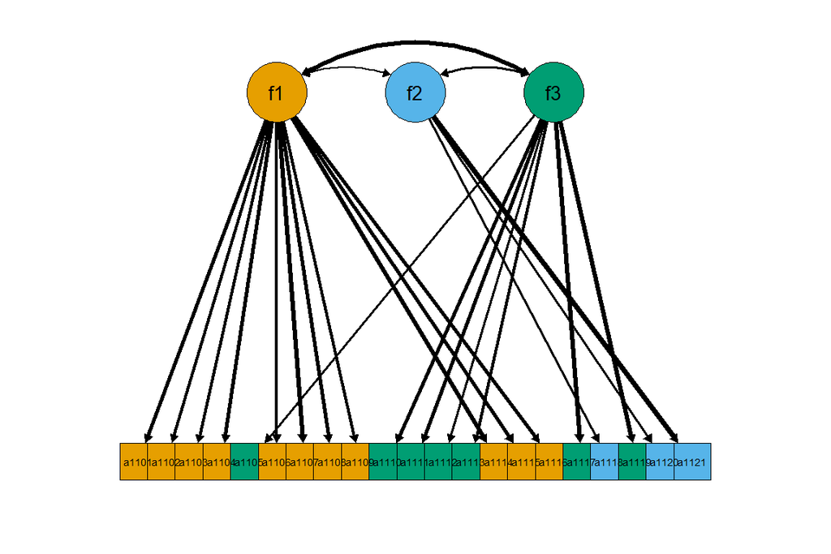

**Standardized Loading Across Folds**

| variable | mean | range | loading flag | heywood flag |
| --- | --- | --- | --- | --- |
| a1101x | 0.70 | 0.60 - 0.79 | 0 | 0 |
| a1102x | 0.59 | 0.52 - 0.66 | 0 | 0 |
| a1103x | 0.65 | 0.60 - 0.68 | 0 | 0 |
| a1104x | 0.76 | 0.71 - 0.80 | 0 | 0 |
| a1105x | 0.49 | 0.45 - 0.57 | 0 | 0 |
| a1106x | 0.71 | 0.68 - 0.74 | 0 | 0 |
| a1107x | 0.78 | 0.75 - 0.81 | 0 | 0 |
| a1108x | 0.77 | 0.72 - 0.80 | 0 | 0 |
| a1109x | 0.63 | 0.60 - 0.67 | 0 | 0 |
| a1110x | 0.70 | 0.65 - 0.74 | 0 | 0 |
| a1111x | 0.75 | 0.68 - 0.80 | 0 | 0 |
| a1112x | 0.49 | 0.43 - 0.55 | 0 | 0 |
| a1113x | 0.70 | 0.66 - 0.74 | 0 | 0 |
| a1114x | 0.80 | 0.77 - 0.83 | 0 | 0 |
| a1115x | 0.76 | 0.72 - 0.81 | 0 | 0 |
| a1116x | 0.79 | 0.76 - 0.83 | 0 | 0 |
| a1117x | 0.87 | 0.83 - 0.89 | 0 | 0 |
| a1118x | 0.55 | 0.40 - 0.63 | 0 | 0 |
| a1119x | 0.86 | 0.83 - 0.88 | 0 | 0 |
| a1120x | 0.59 | 0.47 - 0.71 | 0 | 0 |
| a1121x | 0.86 | 0.77 - 0.93 | 0 | 0 |

Note: loadings flagged when < 0.3 in a fold. ‘heywood flag’ is the number of folds the variable’s estimated residual variance was negative

**Mean Factor Correlations**

|  | f1 | f2 | f3 | flag |
| --- | --- | --- | --- | --- |
| f1 | 1.00 |  |  | 2 |
| f2 | 0.48 | 1.00 |  | 0 |
| f3 | 0.90 | 0.53 | 1.00 | 2 |

Note: ‘flag’ is the number of folds the factor had a correlation > 0.9

**Scale Reliability Across Folds**

| factor | omega_h mean | omega_h range | omega_h flag | alpha mean | alpha range | alpha flag |
| --- | --- | --- | --- | --- | --- | --- |
| f1 | 0.88 | 0.85 - 0.89 | 0 | 0.92 | 0.91 - 0.93 | 0 |
| f2 | 0.57 | 0.48 - 0.60 | 7 | 0.70 | 0.67 - 0.74 | 0 |
| f3 | 0.82 | 0.79 - 0.83 | 0 | 0.86 | 0.85 - 0.87 | 0 |

Note: ‘flag’ is the number of folds the scale had a reliability < 0.6

## 4-factor

**Factor Structure**

f1 =~ a1101x + a1102x + a1103x + a1104x + a1105x + a1106x + a1107x + a1108x + a1109x + a1114x

f2 =~ a1115x + a1116x

f3 =~ a1118x + a1120x + a1121x

f4 =~ a1110x + a1111x + a1112x + a1113x + a1117x + a1119x

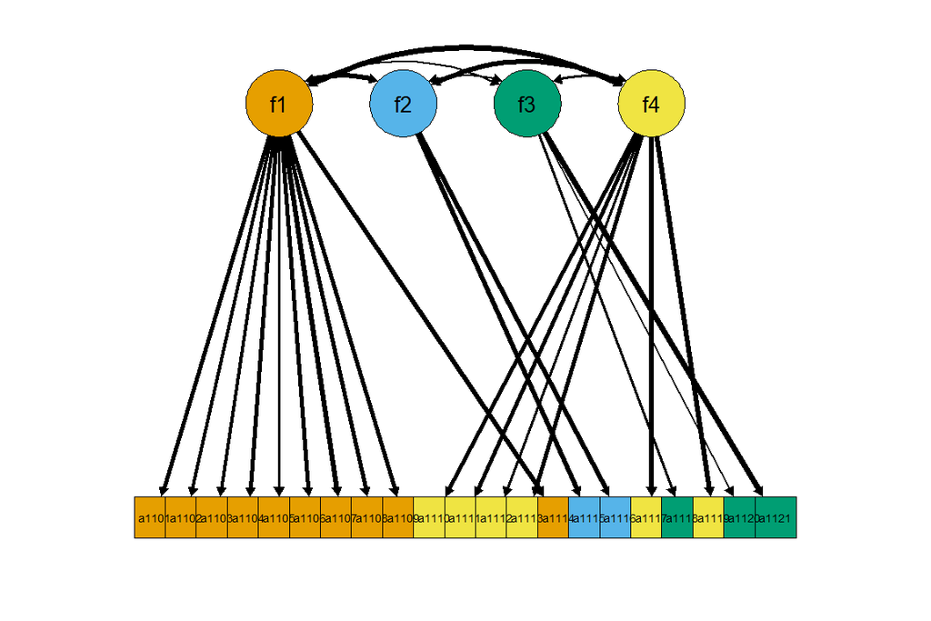

**Standardized Loading Across Folds**

| variable | mean | range | loading flag | heywood flag |
| --- | --- | --- | --- | --- |
| a1101x | 0.73 | 0.68 - 0.79 | 0 | 0 |
| a1102x | 0.60 | 0.54 - 0.66 | 0 | 0 |
| a1103x | 0.65 | 0.60 - 0.68 | 0 | 0 |
| a1104x | 0.76 | 0.72 - 0.78 | 0 | 0 |
| a1105x | 0.47 | 0.44 - 0.52 | 0 | 0 |
| a1106x | 0.72 | 0.68 - 0.73 | 0 | 0 |
| a1107x | 0.78 | 0.75 - 0.81 | 0 | 0 |
| a1108x | 0.78 | 0.75 - 0.81 | 0 | 0 |
| a1109x | 0.64 | 0.61 - 0.68 | 0 | 0 |
| a1110x | 0.70 | 0.65 - 0.75 | 0 | 0 |
| a1111x | 0.74 | 0.68 - 0.78 | 0 | 0 |
| a1112x | 0.48 | 0.43 - 0.53 | 0 | 0 |
| a1113x | 0.69 | 0.66 - 0.74 | 0 | 0 |
| a1114x | 0.80 | 0.79 - 0.82 | 0 | 0 |
| a1115x | 0.80 | 0.75 - 0.82 | 0 | 0 |
| a1116x | 0.84 | 0.81 - 0.86 | 0 | 0 |
| a1117x | 0.87 | 0.84 - 0.89 | 0 | 0 |
| a1118x | 0.50 | 0.37 - 0.60 | 0 | 0 |
| a1119x | 0.86 | 0.84 - 0.88 | 0 | 0 |
| a1120x | 0.55 | 0.44 - 0.68 | 0 | 0 |
| a1121x | 0.83 | 0.74 - 0.91 | 0 | 0 |

Note: loadings flagged when < 0.3 in a fold. ‘heywood flag’ is the number of folds the variable’s estimated residual variance was negative

**Mean Factor Correlations**

|  | f1 | f2 | f3 | f4 | flag |
| --- | --- | --- | --- | --- | --- |
| f1 | 1.00 |  |  |  | 1 |
| f2 | 0.88 | 1.00 |  |  | 1 |
| f3 | 0.49 | 0.48 | 1.00 |  | 0 |
| f4 | 0.88 | 0.87 | 0.53 | 1.00 | 0 |

Note: ‘flag’ is the number of folds the factor had a correlation > 0.9

**Scale Reliability Across Folds**

| factor | omega_h mean | omega_h range | omega_h flag | alpha mean | alpha range | alpha flag |
| --- | --- | --- | --- | --- | --- | --- |
| f1 | 0.85 | 0.84 - 0.86 | 0 | 0.90 | 0.89 - 0.91 | 0 |
| f2 | 0.73 | 0.69 - 0.75 | 0 | 0.80 | 0.76 - 0.82 | 0 |
| f3 | 0.57 | 0.54 - 0.61 | 5 | 0.69 | 0.67 - 0.73 | 0 |
| f4 | 0.82 | 0.79 - 0.83 | 0 | 0.86 | 0.85 - 0.87 | 0 |

Note: ‘flag’ is the number of folds the scale had a reliability < 0.6

## Custom 2f

**Factor Structure**

f1 =~ a1101x + a1102x + a1103x + a1104x + a1105x + a1106x + a1107x + a1108x + a1109x + a1110x

f2 =~ a1111x + a1112x + a1113x + a1114x + a1115x + a1116x + a1117x + a1118x + a1119x + a1120x + a1121x

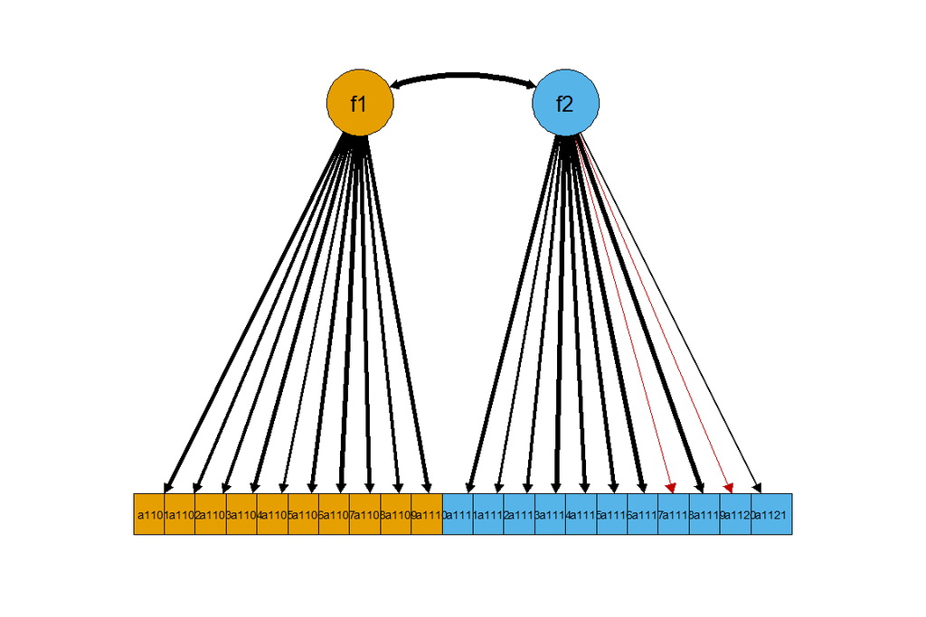

**Standardized Loading Across Folds**

| variable | mean | range | loading flag | heywood flag |
| --- | --- | --- | --- | --- |
| a1101x | 0.71 | 0.62 - 0.79 | 0 | 0 |
| a1102x | 0.59 | 0.53 - 0.65 | 0 | 0 |
| a1103x | 0.65 | 0.59 - 0.68 | 0 | 0 |
| a1104x | 0.76 | 0.72 - 0.80 | 0 | 0 |
| a1105x | 0.48 | 0.44 - 0.57 | 0 | 0 |
| a1106x | 0.72 | 0.68 - 0.74 | 0 | 0 |
| a1107x | 0.79 | 0.75 - 0.81 | 0 | 0 |
| a1108x | 0.78 | 0.74 - 0.81 | 0 | 0 |
| a1109x | 0.64 | 0.61 - 0.68 | 0 | 0 |
| a1110x | 0.69 | 0.63 - 0.74 | 0 | 0 |
| a1111x | 0.71 | 0.65 - 0.76 | 0 | 0 |
| a1112x | 0.49 | 0.43 - 0.55 | 0 | 0 |
| a1113x | 0.67 | 0.63 - 0.70 | 0 | 0 |
| a1114x | 0.81 | 0.78 - 0.84 | 0 | 0 |
| a1115x | 0.76 | 0.71 - 0.81 | 0 | 0 |
| a1116x | 0.79 | 0.77 - 0.83 | 0 | 0 |
| a1117x | 0.86 | 0.83 - 0.89 | 0 | 0 |
| a1118x | 0.33 | 0.22 - 0.40 | 4 | 0 |
| a1119x | 0.85 | 0.83 - 0.87 | 0 | 0 |
| a1120x | 0.35 | 0.25 - 0.41 | 1 | 0 |
| a1121x | 0.49 | 0.42 - 0.54 | 0 | 0 |

Note: loadings flagged when < 0.3 in a fold. ‘heywood flag’ is the number of folds the variable’s estimated residual variance was negative

**Mean Factor Correlations**

|  | f1 | f2 | flag |
| --- | --- | --- | --- |
| f1 | 1.00 |  | 10 |
| f2 | 0.92 | 1.00 | 10 |

Note: ‘flag’ is the number of folds the factor had a correlation > 0.9

**Scale Reliability Across Folds**

| factor | omega_h mean | omega_h range | omega_h flag | alpha mean | alpha range | alpha flag |
| --- | --- | --- | --- | --- | --- | --- |
| f1 | 0.84 | 0.83 - 0.86 | 0 | 0.89 | 0.88 - 0.90 | 0 |
| f2 | 0.85 | 0.83 - 0.86 | 0 | 0.88 | 0.87 - 0.89 | 0 |

Note: ‘flag’ is the number of folds the scale had a reliability < 0.6

## Break

**Factor Structure**

f1 =~ a1101x + a1102x

f2 =~ a1103x + a1104x

f3 =~ a1105x + a1106x

f4 =~ a1107x + a1108x

f5 =~ a1109x + a1110x

f6 =~ a1111x + a1112x

f7 =~ a1113x + a1114x + a1115x + a1116x + a1117x + a1118x + a1119x + a1120x + a1121x

a1101x ~~ a1102x + a1103x + a1104x + a1105x + a1106x + a1107x + a1108x + a1109x + a1110x + a1111x + a1112x + a1113x + a1114x + a1115x + a1116x + a1117x + a1118x + a1119x + a1120x + a1121x

a1102x ~~ a1103x + a1104x + a1105x + a1106x + a1107x + a1108x + a1109x + a1110x + a1111x + a1112x + a1113x + a1114x + a1115x + a1116x + a1117x + a1118x + a1119x + a1120x + a1121x

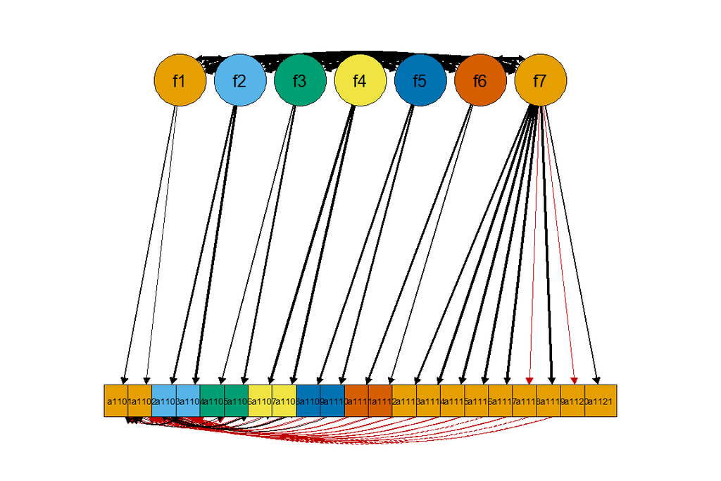

**Standardized Loading Across Folds**

| variable | mean | range | loading flag | heywood flag |
| --- | --- | --- | --- | --- |
| a1101x | 0.48 | 0.44 - 0.51 | 0 | 0 |
| a1102x | 0.31 | 0.26 - 0.36 | 3 | 0 |
| a1103x | 0.67 | 0.61 - 0.73 | 0 | 0 |
| a1104x | 0.78 | 0.74 - 0.84 | 0 | 0 |
| a1105x | 0.48 | 0.42 - 0.60 | 0 | 0 |
| a1106x | 0.71 | 0.63 - 0.77 | 0 | 0 |
| a1107x | 0.83 | 0.77 - 0.88 | 0 | 0 |
| a1108x | 0.82 | 0.77 - 0.86 | 0 | 0 |
| a1109x | 0.58 | 0.50 - 0.64 | 0 | 0 |
| a1110x | 0.64 | 0.58 - 0.73 | 0 | 0 |
| a1111x | 0.78 | 0.69 - 0.85 | 0 | 0 |
| a1112x | 0.53 | 0.46 - 0.59 | 0 | 0 |
| a1113x | 0.67 | 0.63 - 0.70 | 0 | 0 |
| a1114x | 0.81 | 0.78 - 0.84 | 0 | 0 |
| a1115x | 0.76 | 0.71 - 0.81 | 0 | 0 |
| a1116x | 0.79 | 0.77 - 0.83 | 0 | 0 |
| a1117x | 0.87 | 0.83 - 0.89 | 0 | 0 |
| a1118x | 0.33 | 0.21 - 0.41 | 3 | 0 |
| a1119x | 0.85 | 0.83 - 0.87 | 0 | 0 |
| a1120x | 0.36 | 0.25 - 0.42 | 1 | 0 |
| a1121x | 0.50 | 0.43 - 0.54 | 0 | 0 |

Note: loadings flagged when < 0.3 in a fold. ‘heywood flag’ is the number of folds the variable’s estimated residual variance was negative

**Mean Factor Correlations**

|  | f1 | f2 | f3 | f4 | f5 | f6 | f7 | flag |
| --- | --- | --- | --- | --- | --- | --- | --- | --- |
| f1 | 1.00 |  |  |  |  |  |  | 10 |
| f2 | 1.12 | 1.00 |  |  |  |  |  | 10 |
| f3 | 1.08 | 1.05 | 1.00 |  |  |  |  | 10 |
| f4 | 1.00 | 0.91 | 0.96 | 1.00 |  |  |  | 10 |
| f5 | 1.14 | 1.01 | 1.02 | 0.97 | 1.00 |  |  | 10 |
| f6 | 0.81 | 0.78 | 0.87 | 0.76 | 1.04 | 1.00 |  | 10 |
| f7 | 1.27 | 0.89 | 0.92 | 0.87 | 1.04 | 0.91 | 1.00 | 10 |

Note: ‘flag’ is the number of folds the factor had a correlation > 0.9

**Scale Reliability Across Folds**

| factor | omega_h mean | omega_h range | omega_h flag | alpha mean | alpha range | alpha flag |
| --- | --- | --- | --- | --- | --- | --- |
| f1 | 0.11 | 0.08 - 0.13 | 10 | 0.62 | 0.56 - 0.67 | 4 |
| f2 | 0.55 | 0.47 - 0.62 | 9 | 0.69 | 0.63 - 0.76 | 0 |
| f3 | 0.40 | 0.33 - 0.50 | 10 | 0.51 | 0.44 - 0.62 | 9 |
| f4 | 0.71 | 0.63 - 0.78 | 0 | 0.81 | 0.74 - 0.86 | 0 |
| f5 | 0.44 | 0.37 - 0.53 | 10 | 0.54 | 0.46 - 0.62 | 8 |
| f6 | 0.48 | 0.42 - 0.54 | 10 | 0.58 | 0.52 - 0.63 | 6 |
| f7 | 0.83 | 0.81 - 0.85 | 0 | 0.87 | 0.85 - 0.88 | 0 |

Note: ‘flag’ is the number of folds the scale had a reliability < 0.6

# Appendix

## Within Fold Model Fit

| fold | 1-factor df | 1-factor chisq | 1-factor cfi | 1-factor rmsea | 2-factor df | 2-factor chisq | 2-factor cfi | 2-factor rmsea | 3-factor df | 3-factor chisq | 3-factor cfi | 3-factor rmsea | 4-factor df | 4-factor chisq | 4-factor cfi | 4-factor rmsea |
| --- | --- | --- | --- | --- | --- | --- | --- | --- | --- | --- | --- | --- | --- | --- | --- | --- |
| 1 | 189.00 | 675.05 | 0.98 | 0.06 | 188.00 | 437.12 | 0.99 | 0.04 | 186.00 | 370.10 | 0.99 | 0.04 | 183.00 | 345.11 | 0.99 | 0.03 |
| 2 | 189.00 | 614.05 | 0.99 | 0.05 | 188.00 | 351.41 | 0.99 | 0.03 | 186.00 | 299.92 | 1.00 | 0.03 | 183.00 | 284.14 | 1.00 | 0.03 |
| 3 | 189.00 | 675.16 | 0.98 | 0.06 | 188.00 | 374.15 | 0.99 | 0.04 | 186.00 | 332.41 | 0.99 | 0.03 |  |  |  |  |
| 4 | 189.00 | 749.88 | 0.98 | 0.06 | 188.00 | 393.66 | 0.99 | 0.04 | 186.00 | 307.90 | 1.00 | 0.03 |  |  |  |  |
| 5 | 189.00 | 639.37 | 0.99 | 0.05 | 188.00 | 362.20 | 0.99 | 0.03 | 186.00 | 299.48 | 1.00 | 0.03 |  |  |  |  |
| 6 | 189.00 | 612.00 | 0.98 | 0.05 | 188.00 | 349.07 | 0.99 | 0.03 | 186.00 | 282.34 | 1.00 | 0.03 | 183.00 | 268.35 | 1.00 | 0.02 |
| 7 | 189.00 | 640.62 | 0.98 | 0.05 | 188.00 | 416.62 | 0.99 | 0.04 | 186.00 | 382.37 | 0.99 | 0.04 | 183.00 | 347.11 | 0.99 | 0.03 |
| 8 | 189.00 | 684.52 | 0.98 | 0.06 | 188.00 | 442.29 | 0.99 | 0.04 | 186.00 | 373.57 | 0.99 | 0.04 | 183.00 | 347.98 | 0.99 | 0.03 |
| 9 | 189.00 | 678.37 | 0.98 | 0.06 | 188.00 | 402.74 | 0.99 | 0.04 | 186.00 | 345.44 | 0.99 | 0.03 | 183.00 | 325.14 | 0.99 | 0.03 |
| 10 | 189.00 | 555.18 | 0.99 | 0.05 | 188.00 | 388.49 | 0.99 | 0.04 | 186.00 | 323.07 | 0.99 | 0.03 |  |  |  |  |
| Mean | 189.00 | 652.42 | 0.98 | 0.06 | 188.00 | 391.78 | 0.99 | 0.04 | 186.00 | 331.66 | 0.99 | 0.03 | 183.00 | 319.64 | 0.99 | 0.03 |

| fold | Custom 2f df | Custom 2f chisq | Custom 2f cfi | Custom 2f rmsea | Break df | Break chisq | Break cfi | Break rmsea |
| --- | --- | --- | --- | --- | --- | --- | --- | --- |
| 1 | 188.00 | 635.73 | 0.98 | 0.05 | 129.00 | 542.95 | 0.99 | 0.06 |
| 2 | 188.00 | 563.98 | 0.99 | 0.05 | 129.00 | 484.65 | 0.99 | 0.06 |
| 3 | 188.00 | 600.89 | 0.99 | 0.05 | 129.00 | 515.33 | 0.99 | 0.06 |
| 4 | 188.00 | 697.17 | 0.98 | 0.06 | 129.00 | 574.50 | 0.99 | 0.07 |
| 5 | 188.00 | 604.64 | 0.99 | 0.05 | 129.00 | 494.41 | 0.99 | 0.06 |
| 6 | 188.00 | 560.22 | 0.98 | 0.05 | 129.00 | 449.00 | 0.99 | 0.06 |
| 7 | 188.00 | 615.55 | 0.98 | 0.05 | 129.00 | 531.99 | 0.99 | 0.06 |
| 8 | 188.00 | 646.92 | 0.98 | 0.06 | 129.00 | 555.71 | 0.99 | 0.06 |
| 9 | 188.00 | 610.81 | 0.99 | 0.05 | 129.00 | 511.85 | 0.99 | 0.06 |
| 10 | 188.00 | 516.90 | 0.99 | 0.05 | 129.00 | 405.91 | 0.99 | 0.05 |
| Mean | 188.00 | 605.28 | 0.99 | 0.05 | 129.00 | 506.63 | 0.99 | 0.06 |

## All EFA Structures

### Factors: 1

**Factor Structure Option 1**

**In Folds: 1, 2, 3, 4, 5, 6, 7, 8, 9, 10**

f1 =~ a1101x + a1102x + a1103x + a1104x + a1105x + a1106x + a1107x + a1108x + a1109x + a1110x + a1111x + a1112x + a1113x + a1114x + a1115x + a1116x + a1117x + a1118x + a1119x + a1120x + a1121x

### Factors: 2

**Factor Structure Option 1**

**In Folds: 1, 2, 3, 4, 5, 6, 7, 8, 9, 10**

f1 =~ a1101x + a1102x + a1103x + a1104x + a1105x + a1106x + a1107x + a1108x + a1109x + a1110x + a1111x + a1112x + a1113x + a1114x + a1115x + a1116x + a1117x + a1119x

f2 =~ a1118x + a1120x + a1121x

### Factors: 3

**Factor Structure Option 1**

**In Folds: 1, 2, 3, 4, 5, 6, 7, 8, 9, 10**

f1 =~ a1101x + a1102x + a1103x + a1104x + a1106x + a1107x + a1108x + a1109x + a1114x + a1115x + a1116x

f2 =~ a1118x + a1120x + a1121x

f3 =~ a1105x + a1110x + a1111x + a1112x + a1113x + a1117x + a1119x

### Factors: 4

**Factor Structure Option 1**

**In Folds: 1, 2, 6, 7, 8, 9**

f1 =~ a1101x + a1102x + a1103x + a1104x + a1105x + a1106x + a1107x + a1108x + a1109x + a1114x

f2 =~ a1115x + a1116x

f3 =~ a1118x + a1120x + a1121x

f4 =~ a1110x + a1111x + a1112x + a1113x + a1117x + a1119x

**Factor Structure Option 2**

**In Folds: 3, 4, 10**

f1 =~ a1101x + a1102x + a1103x + a1104x + a1106x + a1107x + a1108x + a1109x + a1114x

f2 =~ a1115x + a1116x

f3 =~ a1118x + a1120x + a1121x

f4 =~ a1105x + a1110x + a1111x + a1112x + a1113x + a1117x + a1119x

**Factor Structure Option 3**

**In Folds: 5**

f1 =~ a1101x + a1102x + a1103x + a1104x + a1106x + a1107x + a1108x + a1109x

f2 =~ a1115x + a1116x

f3 =~ a1118x + a1120x + a1121x

f4 =~ a1105x + a1110x + a1111x + a1112x + a1113x + a1114x + a1117x + a1119x

### Factors: 5

**Factor Structure Option 1**

**In Folds: 1, 2, 3, 4, 5, 6, 7, 8, 9, 10**

Structure contained single item factor